# Case Study 2 Markdown

Sam Burch

2022-12-12

# Preliminary

```r
popcorn = read.csv('popcorn.csv', header = TRUE)
popcorn
```

```
##         brand time    kernels rep
## 1     orville   90 0.68000000   1
## 2   essential   90 0.58000000   1
## 3   popsecret   90 0.72000000   1
## 4       actii   90 0.42000000   1
## 5     orville  120 0.14000000   1
## 6   essential  120 0.11000000   1
## 7   popsecret  120 0.15000000   1
## 8       actii  120 0.11000000   1
## 9     orville  180 0.05000000   1
## 10  essential  180 0.05100000   1
## 11  popsecret  180 0.07900000   1
## 12      actii  180 0.02100000   1
## 13    orville   90 0.68282257   2
## 14  essential   90 0.58733613   2
```

[output cut: 106 more lines]

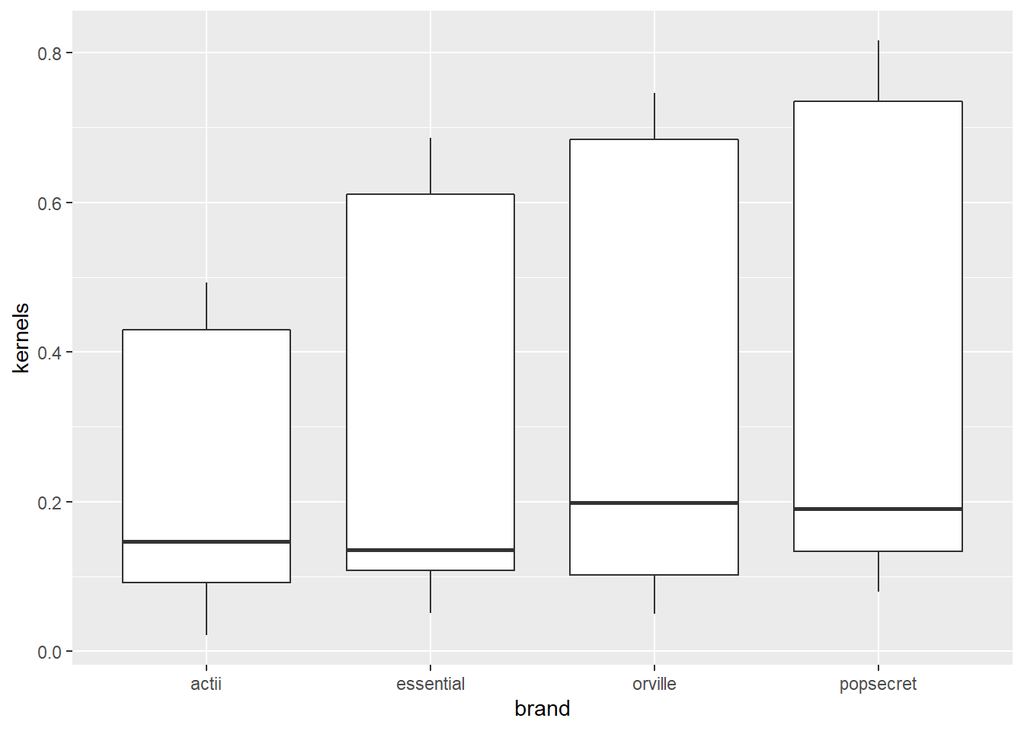

```r
popcorn$brand = as.factor(popcorn$brand)
popcorn$time = as.factor(popcorn$time)
popcorn$rep = as.factor(popcorn$rep)

contrasts(popcorn$brand) = contr.sum(4)
contrasts(popcorn$time) = contr.sum(3)


library(ggplot2)
ggplot(popcorn, aes(brand, kernels)) + geom_boxplot()
```

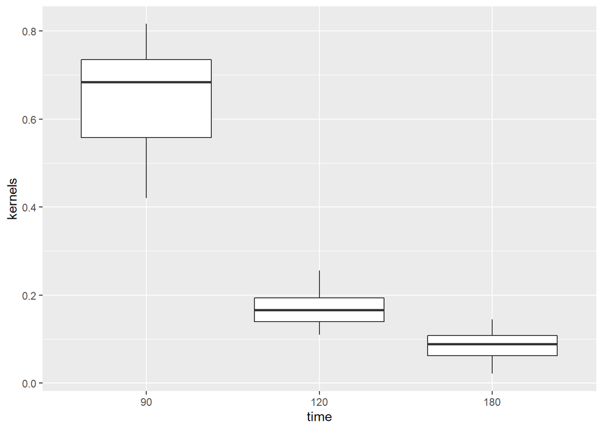

```r
ggplot(popcorn, aes(time, kernels)) + geom_boxplot()
```

Looks as if brands are very similar and percentage goes down as time increases.

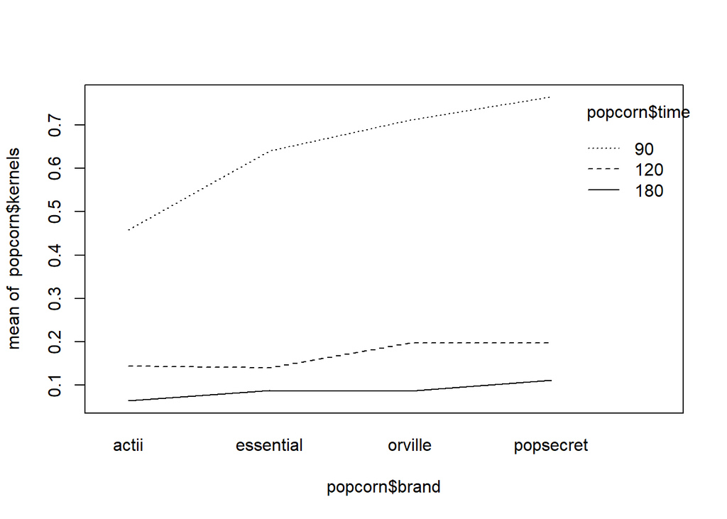

```r
interaction.plot(popcorn$brand, popcorn$time, popcorn$kernels)
```

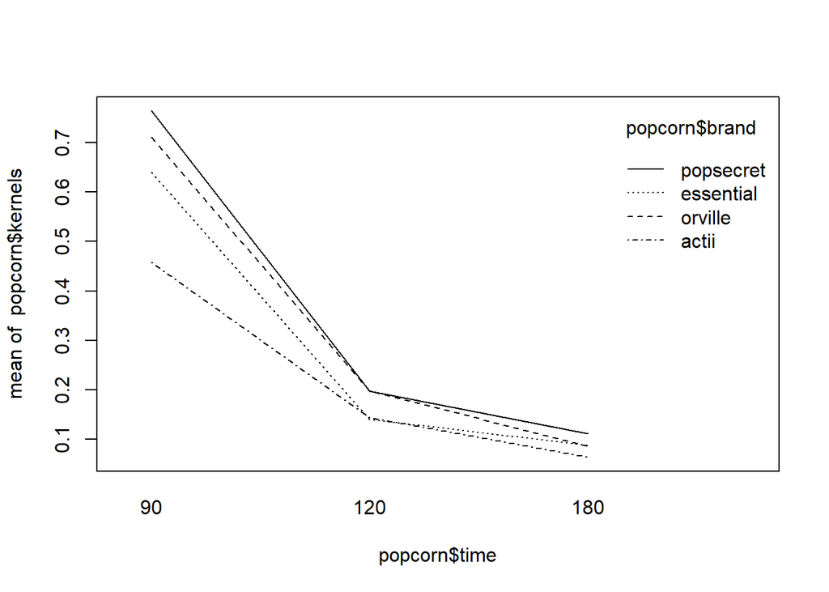

```r
interaction.plot(popcorn$time, popcorn$brand, popcorn$kernels)
```

There seems to be some interaction here due to the intersection of lines.

# Model Selection

```r
popcorn_full = lm(kernels ~ brand * time, data = popcorn)

anova(popcorn_full)
```

```
## Analysis of Variance Table
##
## Response: kernels
##             Df Sum Sq Mean Sq  F value    Pr(>F)
## brand        3 0.3170  0.1057  130.473 < 2.2e-16 ***
## time         2 7.2164  3.6082 4454.722 < 2.2e-16 ***
## brand:time   6 0.2604  0.0434   53.588 < 2.2e-16 ***
## Residuals  108 0.0875  0.0008
## ---
## Signif. codes:  0 '***' 0.001 '**' 0.01 '*' 0.05 '.' 0.1 ' ' 1
```

With the interaction being significant, we stop and select the full model.

# Diagnostics

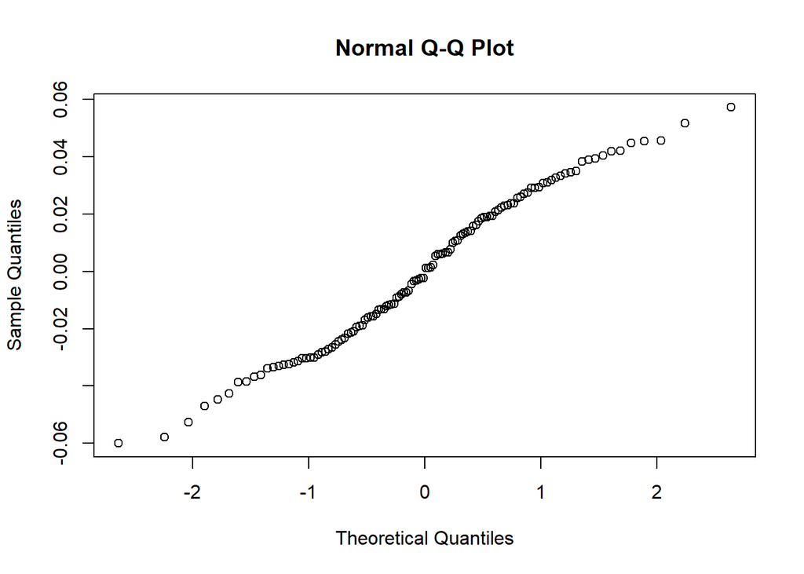

```r
#Checks Normality:
qqnorm(popcorn_full$residuals)
```

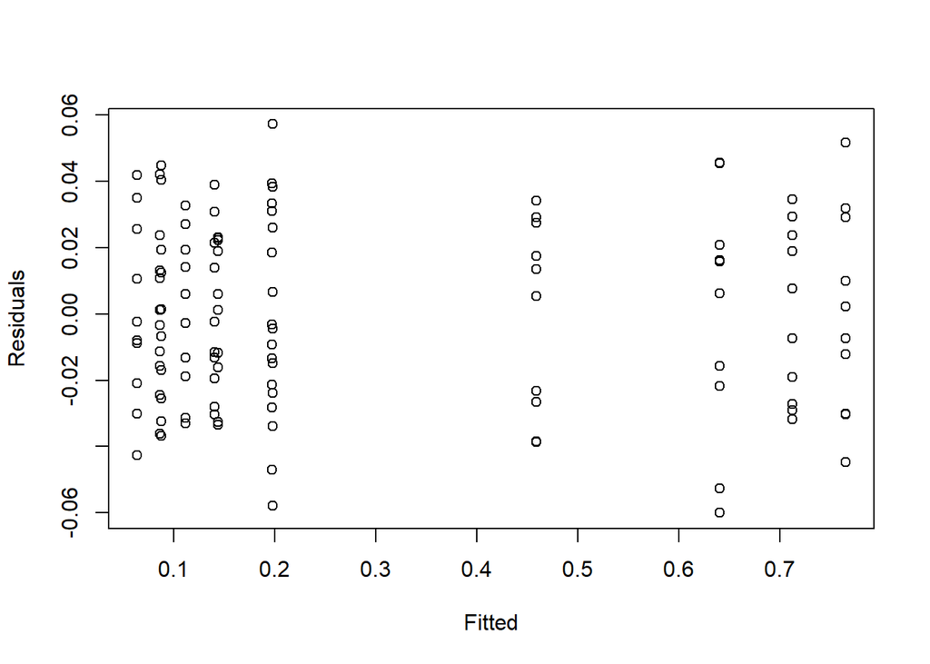

```r
#Checks Constant Variance:
plot(popcorn_full$fitted, popcorn_full$residuals, xlab="Fitted", ylab="Residuals")
```

Variance seems to be constant. Normally may have some issues, let us try box-cox.

```r
library(MASS)
```

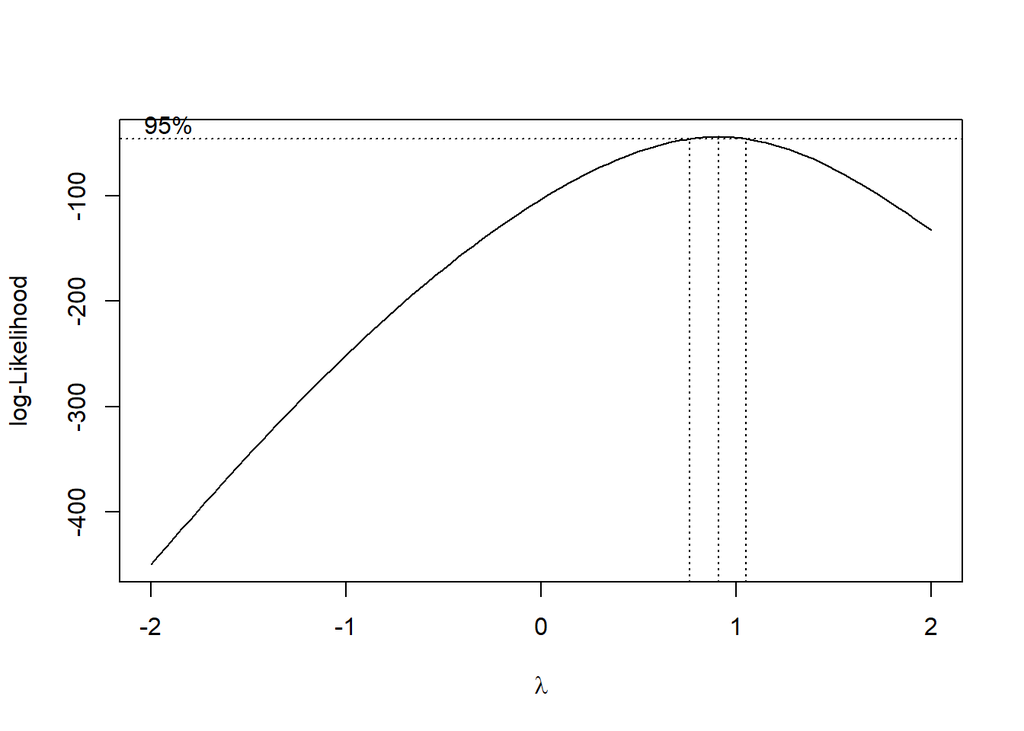

```r
boxcox(popcorn_full)
```

This suggests lambda = 1, so we will NOT be going through with a transformation.

```r
#Checking serial dependence
library(lmtest)
dwtest(popcorn_full$residuals ~ popcorn$rep)
```

```
##
##  Durbin-Watson test
##
## data:  popcorn_full$residuals ~ popcorn$rep
## DW = 2.3831, p-value = 0.9033
## alternative hypothesis: true autocorrelation is greater than 0
```

With DW > 2, there is no serial dependence here.

# Finding MUs and Alphas

```r
summary(popcorn_full)
```

```
##
## Call:
## lm(formula = kernels ~ brand * time, data = popcorn)
##
## Residuals:
##       Min        1Q    Median        3Q       Max
## -0.059966 -0.022088 -0.000598  0.022403  0.057184
##
## Coefficients:
##               Estimate Std. Error t value Pr(>|t|)
## (Intercept)   0.300265   0.002598 115.574  < 2e-16 ***
## brand1       -0.078312   0.004500 -17.403  < 2e-16 ***
## brand2       -0.010915   0.004500  -2.426  0.01694 *
## brand3        0.031668   0.004500   7.037 1.88e-10 ***
## time1         0.343532   0.003674  93.500  < 2e-16 ***
## time2        -0.130613   0.003674 -35.549  < 2e-16 ***
## brand1:time1 -0.106752   0.006364 -16.775  < 2e-16 ***
## brand2:time1  0.007083   0.006364   1.113  0.26818
## brand3:time1  0.036391   0.006364   5.718 9.68e-08 ***
## brand1:time2  0.052138   0.006364   8.193 5.63e-13 ***
## brand2:time2 -0.018378   0.006364  -2.888  0.00469 **
## brand3:time2 -0.003464   0.006364  -0.544  0.58739
## ---
## Signif. codes:  0 '***' 0.001 '**' 0.01 '*' 0.05 '.' 0.1 ' ' 1
##
## Residual standard error: 0.02846 on 108 degrees of freedom
## Multiple R-squared:  0.9889, Adjusted R-squared:  0.9878
## F-statistic: 874.8 on 11 and 108 DF,  p-value: < 2.2e-16
```

```r
mu = .3003


#A's
actili = -.0783                               #1
essential = -.0109                            #2
orville = .0317                               #3
(popsecret = -(essential + orville + actili)) #4
```

```
## [1] 0.0575
```

```r
#actili is the lowest for brand
mu+actili
```

```
## [1] 0.222
```

```r
time_90 = .3435                      #1
time_120 = -.1306                    #2
(time_180 = -(time_120 + time_90))   #3
```

```
## [1] -0.2129
```

```r
#180 is the lowest for time
mu+time_180
```

```
## [1] 0.0874
```

```r
#Interaction A's
actili_90 = -.1068                                            # (1-1)
essential_90 = .0071                                          # (2-1)
orville_90 = .0364                                            # (3-1)
(popsecret_90 = -(actili_90 + essential_90 + orville_90))     # (4-1)
```

```
## [1] 0.0633
```

```r
actili_120 = .0521                                            # (1-2)
essential_120 = -.0184                                        # (2-2)
orville_120 = -.0035                                          # (3-2)
(popsecret_120 = -(actili_120 + essential_120 + orville_120)) # (4-2)
```

```
## [1] -0.0302
```

```r
(actili_180 = -(actili_90 + actili_120))                      # (1-3)
```

```
## [1] 0.0547
```

```r
(essential_180 = -(essential_90 + essential_120))             # (2-3)
```

```
## [1] 0.0113
```

```r
(orville_180 = -(orville_90 + orville_120))                   # (3-3)
```

```
## [1] -0.0329
```

```r
(popsecret_180 = -(actili_180 + essential_180 + orville_180)) # (4-3)
```

```
## [1] -0.0331
```

```r
#OK, but these interaction combinations cannot be interpreted.
```